# HW4 (20')

## Submit as an HTML or PDF file

Print your name (First Name and Last Name) below.

Gahyun Lim

- Import `numpy` and `matplotlib` libraries. Pay attention to the alias.

```python
import numpy as np
import matplotlib.pyplot as plt
```

## 1. For loops to count conditional statements (5')

- Previously, we introduce generating normal vectors using `np.random.normal()`.
- Set the seed value as `100`. (1')
- Generate a random vector that follows a univariate normal distribution with a zero mean and a unit variance with a sample size of `1000` and rename it as `norm_vec`. (1')
- Define an empty list called `eligible_ls`.
- Write a for loop that iterate the entire 1000 samples. Append the value `True` to `eligible_ls` if each random variable lies between $-1.96$ and $1.96$, and `False` otherwise. (2')
- Print out the first five elements of `norm_vec` and `eligible_ls`. (1')

```python
import numpy as np
import matplotlib.pyplot as plt

np.random.seed(100)
norm_vec = np.random.normal(loc=0, scale=1, size=1000)

eligible_ls = []
for x in norm_vec:
    if -1.96 < x < 1.96:
        eligible_ls.append(True)
    else:
        eligible_ls.append(False)

print(norm_vec[:5])
print(eligible_ls[:5])
```

```
[-1.74976547  0.3426804   1.1530358  -0.25243604  0.98132079]
[True, True, True, True, True]
```

## 2. This is a follow-up to question 1. (5')

- If you run `np.sum(list_eligible)`, what value is Python assigning to `True` or `False` elements in the sum? Write you answer as a comment. (1')
- Assign a variable `eligible_sum` to the previous output.
- Print out the type of the output above. (1')
- Convert it to an integer using `int` instead of the previous type. Print out the corresponding value and type. (1')
- Calculate the sample size of numbers who are outside $[-1.96, 1.96]$ using at least **two** methods. (2')
  - You can use subtraction directly.
  - Convert `True` and `False` to $1$ and $0$, respectively; Reverse $0$ and $1$ and calculate the corresponding sum.

```python
np.sum(eligible_ls)
# In the sum, Python assigns True = 1 and False = 0.

eligible_sum = np.sum(eligible_ls)
print(eligible_sum)
print(type(eligible_sum))

eligible_sum_integer = int(eligible_sum)
print(eligible_sum_integer)
print(type(eligible_sum_integer))

# Method 1
count_inside = 0
for num in eligible_ls:
    if num:
        count_inside += 1
    else:
        continue
print (count_inside)
subtraction = len(eligible_ls) - count_inside
print(subtraction)

# Method 2
count_outside = 0
for num in eligible_ls:
    if num == False:
        count_outside += 1
    else:
        continue
print (count_outside)
```

```
937
<class 'numpy.int64'>
937
<class 'int'>
937
63
63
```

## 3. For-Loops + Plotting (5')

Note: The final output should be a 2 dimensional scatter plot with two sets of points, with the $y_1$ and $y_2$ on the vertical axis, and the $x$ values on the horizontal axis. X-axes are labelled as `x`. Y-axes are labelled as `y1` and `y2`, respectively. Titles are labelled as `Scatterplot 1` and `Scatterplot 2`, respectively. Those labeling process should be written inside the for loop for automation workflows.

```
[1 2 3 4 5]
[ 0.          3.75        8.88888889 15.9375     24.96      ]
[0.         0.30103    0.47712125 0.60205999 0.69897   ]
```

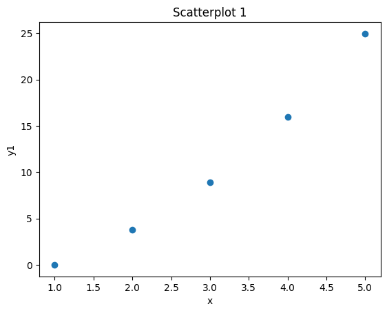

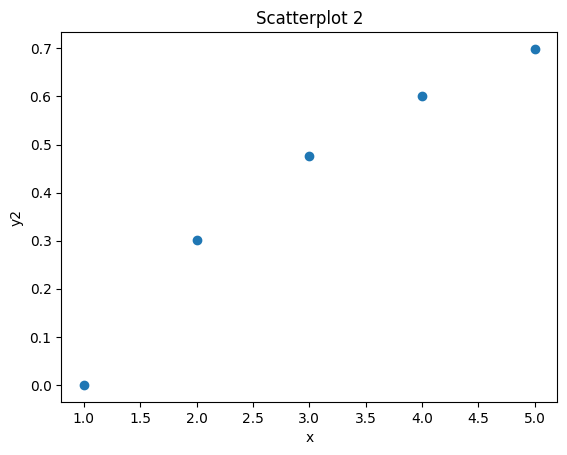

```python
x_vec = np.arange(1, 6)
print(x_vec)

y1_vec = x_vec**2 - x_vec**(-2.0)
y2_vec = np.log10(x_vec)
print(y1_vec)
print(y2_vec)

list_vectors = [y1_vec, y2_vec]

for i, y_vec in enumerate(list_vectors):
    plt.scatter(x_vec, y_vec)
    plt.xlabel("x")
    if i == 0:
        plt.ylabel("y1")
        plt.title("Scatterplot 1")
    else:
        plt.ylabel("y2")
        plt.title("Scatterplot 2")
    plt.show()
```

## 4. While Loops (5')

Write a program to generate the Fibonacci sequence between $0$ and $1000$.  
A Fibonacci sequence is a sequence in which each element is the sum of the two elements that precede it. Define initial values `a=0, b=1`, then the next value is `a+b=1`, so on. The first six values of a Fibonacci sequence given the above initialization is `0,1,1,2,3,5`.

- Create a list `f_ls` that saves the first two initialized values $0$ and $1$.
- Create a `count_id` that can evaluate the last element of the list `f_ls` and define the value as 1.
  - Q: Why do we initialize `count_id` as 1 here?
  - (**Note for TA:** (1') for initialization `f_ls` and `count_id`)
- The condition for the while loop is to evaluate whether the last element of `f_ls` is smaller than $1000$. (1')
- If we pass the while condition, we use the `append` function to compute the next element by summing up the previous two elements. (1')
- Remember to increase `count_id` by 1. (1')
- Print out the final list. Make sure the largest value is smaller than $1000$. (1')

```python
f_ls = [0, 1]
f_ls[0] = 0
f_ls[1] = 1
count_id = 1

while f_ls[count_id] < 1000: #True
    next_num = f_ls[count_id] + f_ls[count_id - 1]
    if next_num >= 1000: #True -> Break
        break
    f_ls.append(next_num)
    count_id += 1

print(f_ls)
```

```
[0, 1, 1, 2, 3, 5, 8, 13, 21, 34, 55, 89, 144, 233, 377, 610, 987]
```